# homework_week_6

```r
knitr::opts_chunk$set(
    echo=TRUE,
    warning=FALSE,
    comment="##",
    prompt=TRUE,
    tidy=TRUE,
    tidy.opts=list(width.cutoff=75),
    fig.path="img/"
)
```

[1] Write a simple R function, Z.prop.test(), that can perform one- or two-sample Z-tests for proportion data, using the following guidelines. *Your function should take the following arguments: p1 and n1 (no default) to pose as the estimated proportion and sample size (i.e., based on your sample data); p2 and n2 (both defaulting to NULL) that contain a second sample’s proportion and sample size data in the event of a two-sample test; p0 (no default) as the expected value for the population proportion; and alternative (default “two.sided”) and conf.level (default 0.95), to be used in the same way as in the function t.test().* When conducting a two-sample test, it should be p1 that is tested as being smaller or larger than p2 when alternative=“less” or alternative=“greater”, the same as in the use of x and y in the function t.test(). *The function should perform a one-sample Z-test using p1, n1, and p0 if either p2 or n2 (or both) is NULL.* The function should contain a check for the rules of thumb we have talked about ($n * p > 5$ and $n * (1-p) >5$) to ensure the validity of assuming the normal distribution in both the one- and two-sample settings. If this is violated, the function should still complete but it should also print an appropriate warning message. *The function should return a list containing the members Z (the test statistic), P (the appropriate p-value), and CI (the two-sided CI with respect to confidence level). #number one

```r
> # calculating z statistic equation
> # z= Phat-P0/SE(Phat) = Phat-P0/(sqrt(pq/n))
> # CI = estimate +- margin of error
>
> z.prop.test <- function(p1,n1,p2=NULL, n2=NULL, p0, alternative="two.sided", conf.level=0.95) #these are the functions arguments
+   {
+   if((p2=NULL)||(n2=NULL)) { #this is a one-sample z test
+   se.p1<- sqrt((p0*1-p0)/n1)
+   z<- (p1-p0)/se.p1 #this is the z test = (phat-p0/se(phat))
+   p.val<- pnorm(z) #p value of test
+   ci<- p1 + c(-1*((qnorm(((1-conf.level)/2)+ con.level))*se.p1), ((qnorm(((1-conf.level)/2)+ conf.level))*se.p1))
+     if(n1*p1<=5||n1*(1-p1)<=5){ #check for the rules of thumb- data should be normally distributed, test will still run but the below cuidado message will be printed
+       warning("CUIDADO: Sample may not be normally distributed, and does not meet assumptions for a Z-test") #end of the code for the one sample z test
+     }
+   else{
+   if(p1*n1<=5||n1*(1-p1)<=5||p2*n2<=5||n2*(1-p2<=5)) { #this tests to see if the sample size is large enough to run the Z test
+   warning("CUIDADO: Sample my not be normally distributed, and does not meet assumptions for a z-test")
+   }
+   p.star<- (p1*n1+p2*n2)/(n1+n2) #pooled proportion of probabilities
+   z<- (p1-p2-p0)/sqrt(p.star*(1-p.star)*(1/n1+1/n2)) #this is the code for the two-sample z-test (estimate +- margin of error)
+   ci<-(p1-p2)+c(-1,1)*qnorm(conf.level+(1-conf.level)/2)*sqrt(p.star*(1-p.star)*(1/n1+1/n2)) #confidence interval for two sample test
+   }
+   if(alternative=="two.sided"){
+     if (z>0){
+       p.val<- 2*pnorm(z, lower.tail=FALSE)#multiplied by 2 because it is a two-sample z-test
+     }
+   }
+     if(z<0){
+       p.val<- 2*pnorm(z, lower.tail=TRUE)
+     }
+   if(alternative=="greater"){
+     p.val<- pnorm(z, lower.tail=FALSE) #calculates the associated p value
+   }
+   if(alternative== "less"){
+     p.val <- pnorm(z, lower.tail = TRUE) #calculates associated p value
+   }
+   return(list(z, p, ci))
+   }
+ }
```

[2] The dataset from Kamilar and Cooper has in it a large number of variables related to life history and body size. For this exercise, the end aim is to fit a simple linear regression model to predict longevity (“MaxLongevity_m”) measured in months from species’ brain size (“Brain_Size_Species_Mean”) measured in grams. Do the following for both longevity~brain size and log(longevity)~log(brain size).

*Fit the regression model and, using {ggplot2}, produce a scatterplot with the fitted line superimposed upon the data. Append the the fitted model equation to your plot (HINT: use the function geom_text()).* Identify and interpret the point estimate of the slope ($\beta_1$), as well as the outcome of the test associated with the hypotheses H0: $\beta_1$ = 0; HA: $\beta_1$ ≠ 0. Also, find a 90 percent CI for the slope ($\beta_1$) parameter. *Using your model, add lines for the 90 percent confidence and prediction interval bands on the plot and add a legend to differentiate between the lines.* Produce a point estimate and associated 90 percent PI for the longevity of a species whose brain weight is 800 gm. Do you trust the model to predict observations accurately for this value of the explanatory variable? Why or why not? *Looking at your two models, which do you think is better? Why?

# number two

*Fit the regression model and, using {ggplot2}, produce a scatterplot with the fitted line superimposed upon the data. Append the the fitted model equation to your plot (HINT: use the function geom_text()).

```r
> f <- file.choose()  #uploading data into R
> f
```

```
## [1] "C:\\Users\\Allison\\Desktop\\GitHub\\ADA\\KamilarAndCooperData.csv"
```

```r
> d <- read.csv(f)
> head(d)
```

```
##               Scientific_Name          Family          Genus      Species
## 1 Allenopithecus_nigroviridis Cercopithecidae Allenopithecus nigroviridis
## 2         Allocebus_trichotis Cercopithecidae      Allocebus    trichotis
## 3           Alouatta_belzebul        Atelidae       Alouatta     belzebul
## 4             Alouatta_caraya        Atelidae       Alouatta       caraya
## 5            Alouatta_guariba        Atelidae       Alouatta      guariba
## 6           Alouatta_palliata        Atelidae       Alouatta     palliata
##   Brain_Size_Species_Mean Brain_Size_Female_Mean   Brain_size_Ref
## 1                   58.02                  53.70 Isler et al 2008
## 2                      NA                     NA
## 3                   52.84                  51.19 Isler et al 2008
## 4                   52.63                  47.80 Isler et al 2008
## 5                   51.70                  49.08 Isler et al 2008
## 6                   49.88                  48.04 Isler et al 2008
##   Body_mass_male_mean Body_mass_female_mean Mass_Dimorphism
```

[output cut: 69 more lines]

```r
> library(ggplot2)
>
> m <- lm(data = d, MaxLongevity_m ~ Brain_Size_Species_Mean)  #creates linear regression model
> m
```

```
##
## Call:
## lm(formula = MaxLongevity_m ~ Brain_Size_Species_Mean, data = d)
##
## Coefficients:
##             (Intercept)  Brain_Size_Species_Mean
##                 248.952                    1.218
```

```r
> m$coefficients
```

```
##             (Intercept) Brain_Size_Species_Mean
##               248.95227                 1.21799
```

```r
> head(m$model)
```

```
##   MaxLongevity_m Brain_Size_Species_Mean
## 1          276.0                   58.02
## 4          243.6                   52.63
## 6          300.0                   49.88
## 7          240.0                   51.13
## 8          300.0                   55.22
## 9          360.0                   20.67
```

```r
> brain_size <- d$Brain_Size_Species_Mean
> maximum_longevity <- d$MaxLongevity_m
> head(m)
```

[output not shown]

[output not shown]

```r
> summary(m)  #shows summary of the model data
```

```
##
## Call:
## lm(formula = MaxLongevity_m ~ Brain_Size_Species_Mean, data = d)
##
## Residuals:
##     Min      1Q  Median      3Q     Max
## -198.27  -61.92  -17.78   56.16  331.36
##
## Coefficients:
##                         Estimate Std. Error t value Pr(>|t|)
## (Intercept)             248.9523    11.1111   22.41   <2e-16 ***
## Brain_Size_Species_Mean   1.2180     0.1101   11.06   <2e-16 ***
## ---
## Signif. codes:  0 '***' 0.001 '**' 0.01 '*' 0.05 '.' 0.1 ' ' 1
##
## Residual standard error: 90.91 on 126 degrees of freedom
##   (85 observations deleted due to missingness)
## Multiple R-squared:  0.4928, Adjusted R-squared:  0.4887
## F-statistic: 122.4 on 1 and 126 DF,  p-value: < 2.2e-16
```

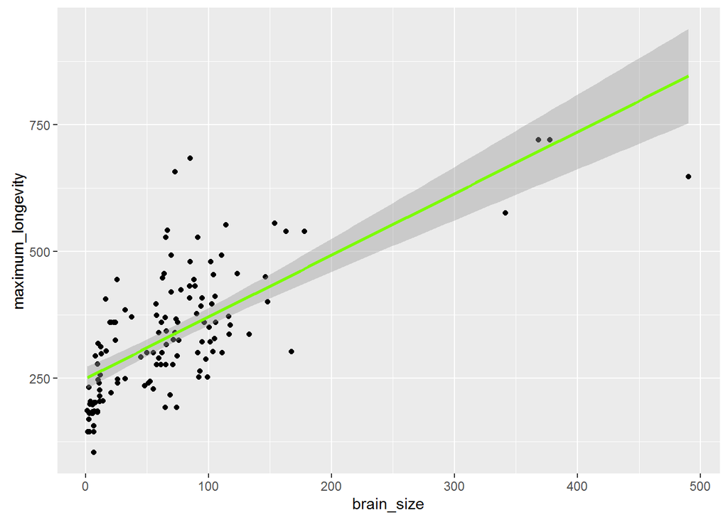

```r
> g <- ggplot(data = d, aes(x = brain_size, y = maximum_longevity))
> g <- g + geom_point()
> g <- g + geom_smooth(method = "lm", formula = y ~ x, color = "lawngreen")
> g  #I am getting a warning message with this line of code that 85 rows have been removed due to non-finite values and missing values
```